# R Notebook

# Time Series Regression for Predicting Price Index for Alcoholic Beverages and Tobacco

Ömer Anıl Usta - IE360 - Fall20 - HW3 09/01/2020

## 1.Introduction

Forecasting can be done in many methods. Most common one of these methods is regression models. Regression models uses predictors which are also data that are correlated to the target data. It basically gives a calculation that can easyily be used to estimate and predict the target data.

The data investigated in this study is the **Price Index of Alcoholic Beverages and Tobacco** in Turkey. Data in hand is monthly estimates from March 2014 to November 2020. Aim of this study is coming up with a regression model and predict the next month’s estimate which is December 2020.

At the start this study has many data at hand that may or may not be correlated to the target price index therefore may or may not be used while coming up with a regression model. Different data at hand are of course our target Price Index of Alcoholic Beverages and Tobacco, Consumer Price Index, Euro/Turkish Lira exchange rate, Current Situation of the Economy(Compared to 12 months ago), Current Financial Situation of the Household, Total Revenue from Alcohol Consumption, The amount of money spent in places of drinking alcohol and The number of transactions made places of drinking alcohol. Unfortunately there weren’t any available series about tobacco production/use that had data until November 2020.

- Considering the correlation of **CPI** to the prices of alcohol and tobacco it can be said that there would probably be a positive correlation. When the price of everything in a market increases, this change would eventually effect the prices of alcoholic beverages and tobacco products.
- The **exchange rate of Euro** would effect the alcohol prices as well. Since many alcohol brands are foreign if exchange rate increased, Tl prices of the product would also increase, therefore there is a positive correlation.
- **Current Economic Situation** and the **Current Financial Situation of the Household** would effect alcohol and tobacco prices the same way. Since finance of a household would be effected by the economy. It is hard to say how these measures would effect our target data.
- **Total Revenue from Alcohol Consumption**, **The amount of money spent in places of drinking alcohol** and **The number of transactions made places of drinking alcohol** would also effect the alcohol and tobacco prices the same way. It is hard to predict how they would correlate to the alcohol prices. If alcohol prices increased the revenue per product would increase but demand would decrease.

From the data at hand this study tries to find correlations. Series with correlation are treated like they are predictors for the regression model. Then these predictors are investigated if they really correlate in the model to the target data. Regression model created is tested if it really fit for predicting the target value. And finally, using this regression model the prediction is made.

## 2.Manipulation and Visualization

The data investigated in this study is the Price Index of Alcoholic Beverages and Tobacco in Turkey. Data in hand is monthly estimates from March 2014 to November 2020. Aim of this study is coming up with a regression model and predict the next month’s estimate which is December 2020. Now let’s look at the measures in the data table below that will be used to create a regression model for the Price Index of alcohol and tobacco.

| Date | Casino1 | Casino | Euro | alcandtob | CPI | Household | Economy | Alcohol |
| --- | --- | --- | --- | --- | --- | --- | --- | --- |
| 2014-03-01 | 37673 | 628558 | 3.065771 | 412.57 | 237.18 | 78.71098 | 95.81962 | 349909 |
| 2014-04-01 | 38121 | 595204 | 2.938243 | 412.67 | 240.37 | 79.56918 | 102.47644 | 461742 |
| 2014-05-01 | 47517 | 786878 | 2.874480 | 412.05 | 241.32 | 78.14959 | 98.82933 | 500456 |
| 2014-06-01 | 40286 | 678639 | 2.875757 | 411.81 | 242.07 | 82.01820 | 95.10513 | 591917 |
| 2014-07-01 | 24100 | 531871 | 2.876425 | 420.02 | 243.17 | 79.72684 | 96.51230 | 655271 |
| 2014-08-01 | 58318 | 975943 | 2.876857 | 418.09 | 243.40 | 77.16433 | 99.38484 | 314727 |

For clarification “Casino1” stands for “The amount of money spent in places of drinking alcohol/Thousand Tl”, “Casino” stands for “The number of transactions made places of drinking alcohol”, “Euro” stands for “Exchange rate of Euro/Tl”, “alcandtob” stands for “Price index of alcoholic beverages and tobacco”, “CPI” stands for “General consumer price index”, “Household” stands for “Current financial situation of the household”, “Economy” stands for “Current economic situation(compared to 12 moths ago)”, “Alcohol” stands for “Revenues from alcoholic beverages/Thousand Tl”. In the following parts data will be referred with these abbreviations.

These data types are canditates to be used in a regression model to predict the price index of alcoholic beverages and tobacco in December 2020. We will analyze the data and pick the ones that is correlated to our core data type.

Now observe the monthly change in alcohol and tobacco prices over the years from 2014 to 2020.

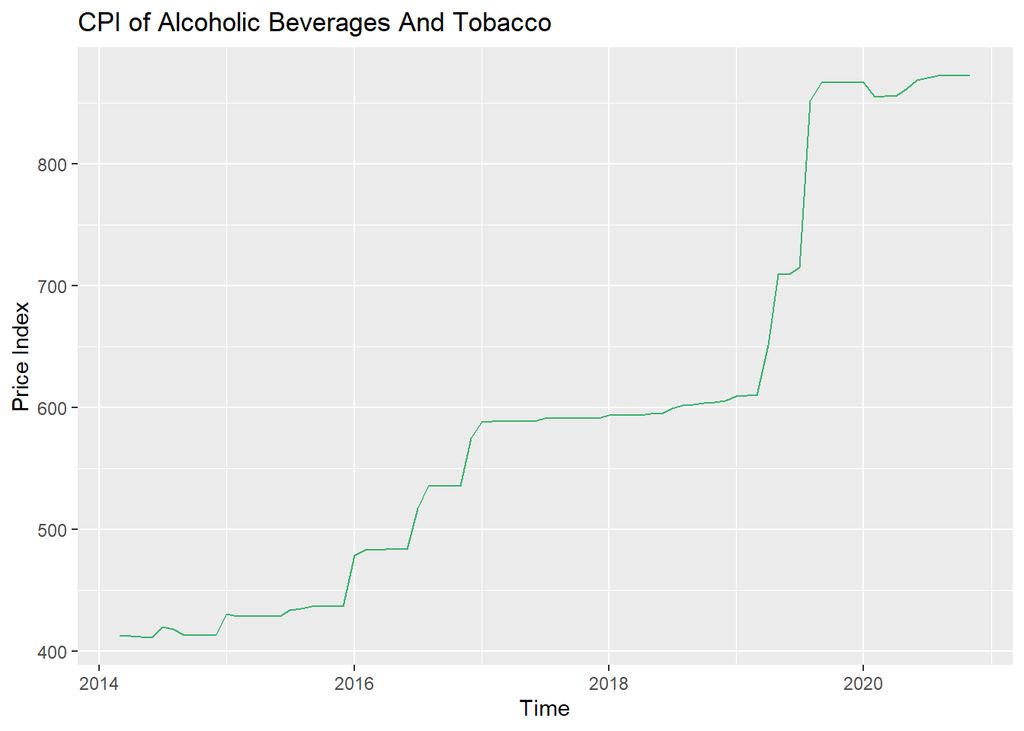

This grapch seems volatile therefore the logarithm of the data is taken and the new graph is drawn below.

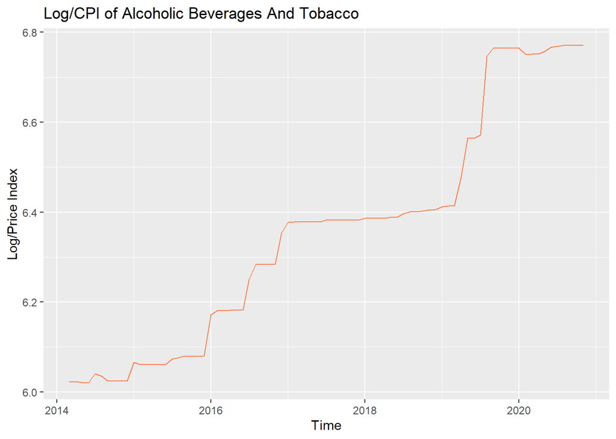

There isn’t enough change in the volatility of the graph. For that reason the **first iteration of the data will be used** to create a regression model.

## 3.Regression Predictors

The data did not show seasonality in the graph but lets test the data to see if there is a seasonality that was not visible in its graph.

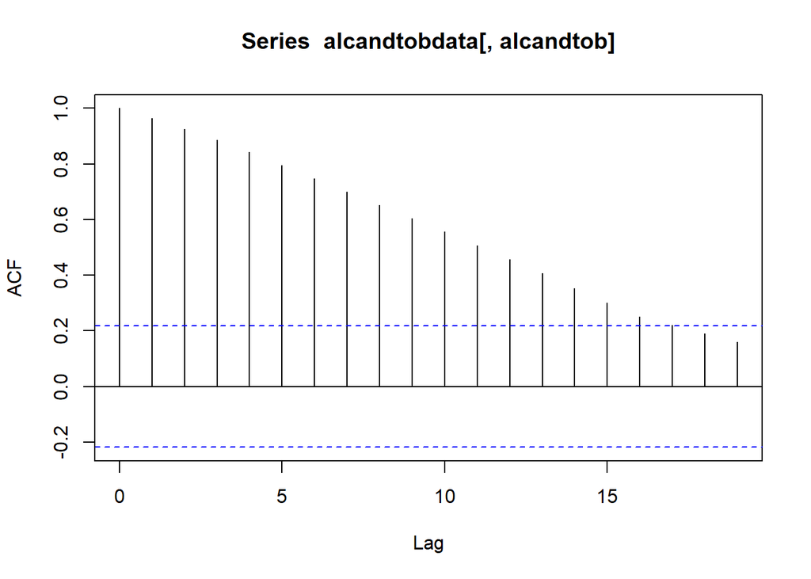

Just like observed there is not any seasonality since the AutoCorrelation Function did not show any lag in the data. Now we will contione to pick and choose the predictors for the regression model.

It is logical to check the one on one correlations of the different data at hand. Below is a correlation matrix of all the types of data at hand. Investigating the correlations of alcohol and tobacco price index(alcandtob) will give which types are correlated and can be used as predictors.

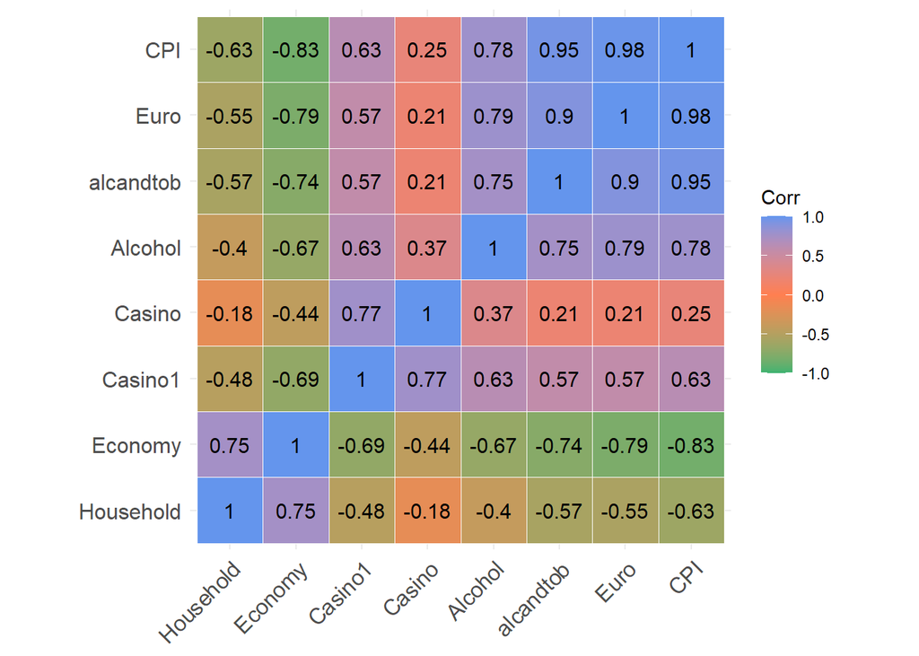

After analyzing the correlation matrix above it can be said that *Consumer Price Index, Euro exchange rate, Revenue from alcohol and Current economic Situation are correlated* to alcoholic beverage and tobacco price index. *Household financial situation and The amount of money spent in places of drinking alcohol are somewhat correlated*. The number of transactions made places of drinking alcohol is not necessarily correlated.

## 4.Regression Model

Now let’s check the ones that are correlated if they give out a fit regression model.

```
##
## Call:
## lm(formula = alcandtob ~ Euro + CPI + Casino1 + Alcohol + Household +
##     Economy, data = alcandtobdata)
##
## Residuals:
##      Min       1Q   Median       3Q      Max
## -102.284  -17.775    1.403   17.450   74.046
##
## Coefficients:
##               Estimate Std. Error t value Pr(>|t|)
## (Intercept) -7.709e+02  1.596e+02  -4.831 7.16e-06 ***
## Euro        -8.592e+01  1.243e+01  -6.911 1.44e-09 ***
## CPI          4.124e+00  3.118e-01  13.226  < 2e-16 ***
## Casino1     -3.010e-04  1.375e-04  -2.190   0.0317 *
## Alcohol      4.197e-05  1.772e-05   2.368   0.0205 *
## Household    3.209e+00  2.059e+00   1.559   0.1233
## Economy      1.719e+00  7.991e-01   2.152   0.0347 *
## ---
## Signif. codes:  0 '***' 0.001 '**' 0.01 '*' 0.05 '.' 0.1 ' ' 1
##
## Residual standard error: 36.85 on 74 degrees of freedom
## Multiple R-squared:  0.9485, Adjusted R-squared:  0.9443
## F-statistic: 227.2 on 6 and 74 DF,  p-value: < 2.2e-16
```

Euro exchange rate and CPI turns out to be extremely correlated. “Casino1”, “Alcohol” and “Economy” are also correlated. “Household” is not correlated. p-value is low and R-squared value is 0.9485. This could be used as a regression model.

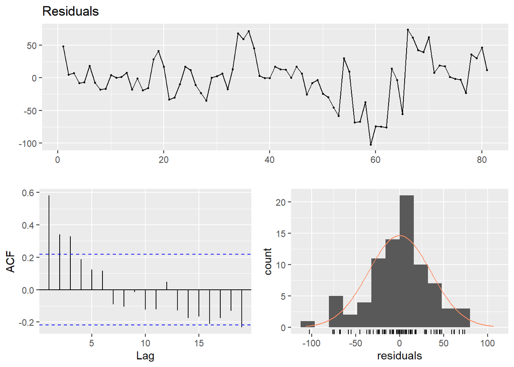

```
##
##  Breusch-Godfrey test for serial correlation of order up to 10
##
## data:  Residuals
## LM test = 37.835, df = 10, p-value = 4.054e-05
```

This model seems to be fine; mean of the residuals seem to be 0, distribution resembles normal distribution. But this model has an excess predictor. “Household” which is current financial situation of the household is not correlated to the target data. Therefore this data is taken out of the model. New regression model can be seen below.

```
##
## Call:
## lm(formula = alcandtob ~ Euro + CPI + Casino1 + Alcohol + Economy,
##     data = alcandtobdata)
##
## Residuals:
##      Min       1Q   Median       3Q      Max
## -108.023  -17.416    3.033   18.277   80.396
##
## Coefficients:
##               Estimate Std. Error t value Pr(>|t|)
## (Intercept) -5.677e+02  9.296e+01  -6.107 4.15e-08 ***
## Euro        -7.929e+01  1.179e+01  -6.723 3.05e-09 ***
## CPI          3.944e+00  2.924e-01  13.491  < 2e-16 ***
## Casino1     -2.753e-04  1.378e-04  -1.998  0.04933 *
## Alcohol      4.620e-05  1.768e-05   2.614  0.01081 *
## Economy      2.398e+00  6.765e-01   3.545  0.00068 ***
## ---
## Signif. codes:  0 '***' 0.001 '**' 0.01 '*' 0.05 '.' 0.1 ' ' 1
##
## Residual standard error: 37.2 on 75 degrees of freedom
## Multiple R-squared:  0.9468, Adjusted R-squared:  0.9433
## F-statistic:   267 on 5 and 75 DF,  p-value: < 2.2e-16
```

In this model, there is a new data that shows significant correlation. p-value is low, R-squared is 0,9433. This model seems to be a good fit for our target data.

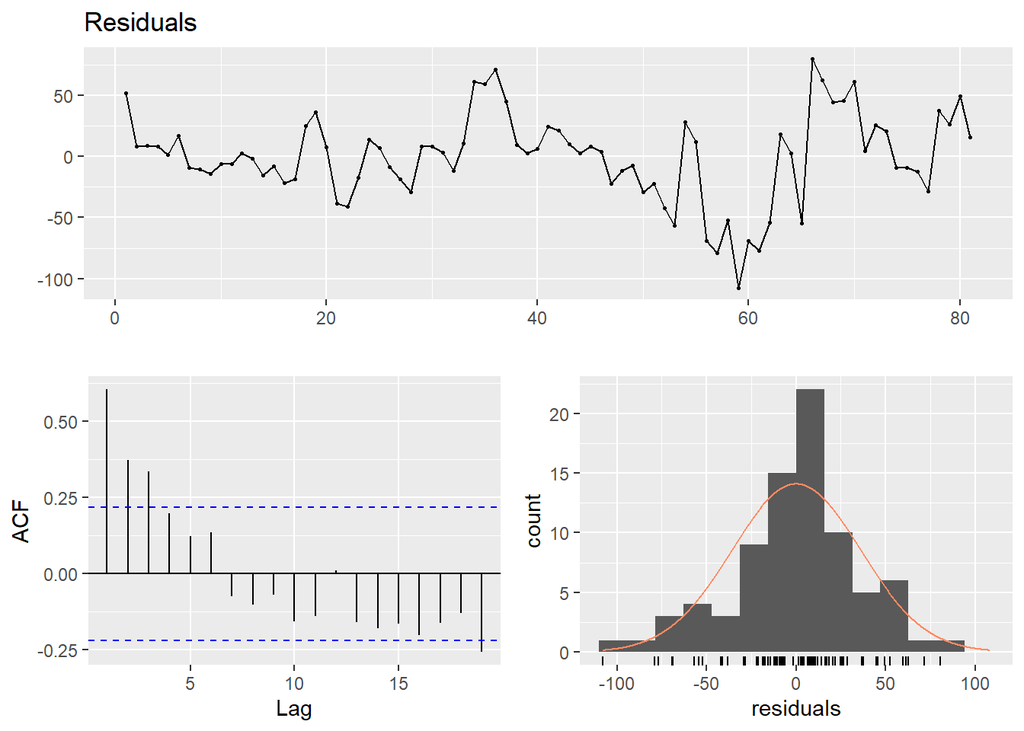

```
##
##  Breusch-Godfrey test for serial correlation of order up to 10
##
## data:  Residuals
## LM test = 40.267, df = 10, p-value = 1.521e-05
```

Residual means looks close to 0. Distribution resembles normal distribution more in this iteration. This regression model can very well be used predicting the price index of alcoholic drinks and tobacco.

## 5.Testing the Model

Now we should test the model. Firstly we check the residuals of the regression model. We are looking for residuals averaging 0 and are scattered.

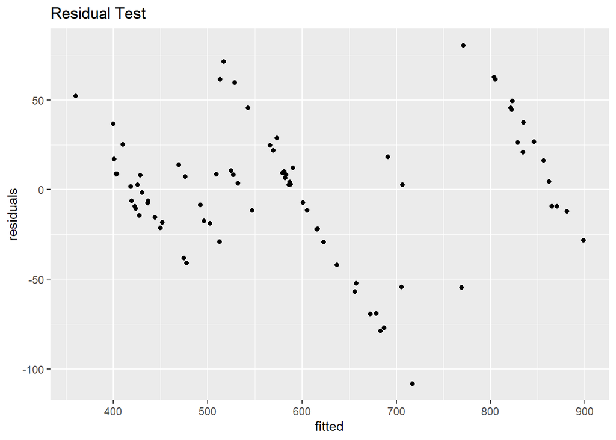

Residuals look to be scattered equally around 0. There seems to be a pattern of decreasing residuals. This can be expected because the data have such sudden and large increases. Therefore this model can possibly be fit for the target data.

Next we compare the actual amount and the predicted amount of price index of alcohol and tobacco. We expect the values to be around the identity line.

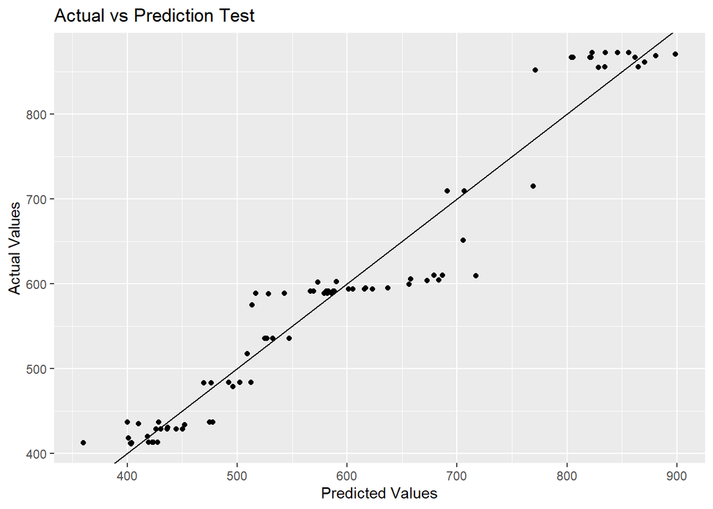

Once again this test gives us a pattern of intersections. This is also explained by the sudden increases in data and predictions catching up to the actual values in time. This test also approves the regression model.

## 6.Prediction

Now that there is a regression model that is fit to our data we can predict the next months alcoholic beverages and tobacco price index. We will come up with a prediction for December of 2020 therefore we have to use the values of predictors at 2020 December. The data of Consumer Price Index, Euro exchange rate, Current economic Situation and The amount of money spent in places of drinking alcohol are all available in EVDS.

| Date | Casino1 | Casino | Euro | alcandtob | CPI | Household | Economy | Alcohol | trend | fitted_alc | fitted | residuals |
| --- | --- | --- | --- | --- | --- | --- | --- | --- | --- | --- | --- | --- |
| 2020-07-01 | 113664 | 816343 | 7.820976 | 870.40 | 468.56 | 70.79534 | 73.78957 | 2006291 | 77 | 1429207 | 898.6009 | -28.20093 |
| 2020-08-01 | 115990 | 822491 | 8.575790 | 872.12 | 472.61 | 72.92962 | 68.61660 | 1853691 | 78 | 1562831 | 834.6282 | 37.49185 |
| 2020-09-01 | 97944 | 716664 | 8.860750 | 872.47 | 477.21 | 72.20644 | 71.91926 | 1912957 | 79 | 1613277 | 845.8032 | 26.66683 |
| 2020-10-01 | 116741 | 854771 | 9.273705 | 872.40 | 487.38 | 73.25634 | 66.25666 | 1664917 | 80 | 1686383 | 822.9560 | 49.44396 |
| 2020-11-01 | 54846 | 393780 | 9.457200 | 872.43 | 498.58 | 71.74885 | 61.07859 | 1645411 | 81 | 1718867 | 856.2992 | 16.13085 |
| 2020-12-01 | 24283 | NA | 9.380000 | NA | 504.81 | NA | 60.89000 | NA | 82 | NA | NA | NA |

Column “fitted” in the table below shows the prediction of the regression model in that month. Column “residuals” refers to the residual differences between the actual price index and predicted price index of alcohol and tobacco.

**The value of Revenue from alcohol consumption for December 2020 isn’t available. Regression model for this value was also created and the December 2020 value was predicted by this model. This model isn’t available on this page but it can be found in the code.** Column “fitted_alc” refers to the predicted revenue from alcohol consumption. Below is the last iteration of the table that includes all the necessery data in December 2020 for all predictor data types.

| Date | Casino1 | Casino | Euro | alcandtob | CPI | Household | Economy | Alcohol | trend | fitted_alc | fitted | residuals |
| --- | --- | --- | --- | --- | --- | --- | --- | --- | --- | --- | --- | --- |
| 2020-07-01 | 113664 | 816343 | 7.820976 | 870.40 | 468.56 | 70.79534 | 73.78957 | 2006291 | 77 | 1429207 | 898.6009 | -28.20093 |
| 2020-08-01 | 115990 | 822491 | 8.575790 | 872.12 | 472.61 | 72.92962 | 68.61660 | 1853691 | 78 | 1562831 | 834.6282 | 37.49185 |
| 2020-09-01 | 97944 | 716664 | 8.860750 | 872.47 | 477.21 | 72.20644 | 71.91926 | 1912957 | 79 | 1613277 | 845.8032 | 26.66683 |
| 2020-10-01 | 116741 | 854771 | 9.273705 | 872.40 | 487.38 | 73.25634 | 66.25666 | 1664917 | 80 | 1686383 | 822.9560 | 49.44396 |
| 2020-11-01 | 54846 | 393780 | 9.457200 | 872.43 | 498.58 | 71.74885 | 61.07859 | 1645411 | 81 | 1718867 | 856.2992 | 16.13085 |
| 2020-12-01 | 24283 | NA | 9.380000 | NA | 504.81 | NA | 60.89000 | 1705200 | 82 | 1705200 | NA | NA |

Now lets compare the actual values with the predicted ones on a graph and see how well the model works.

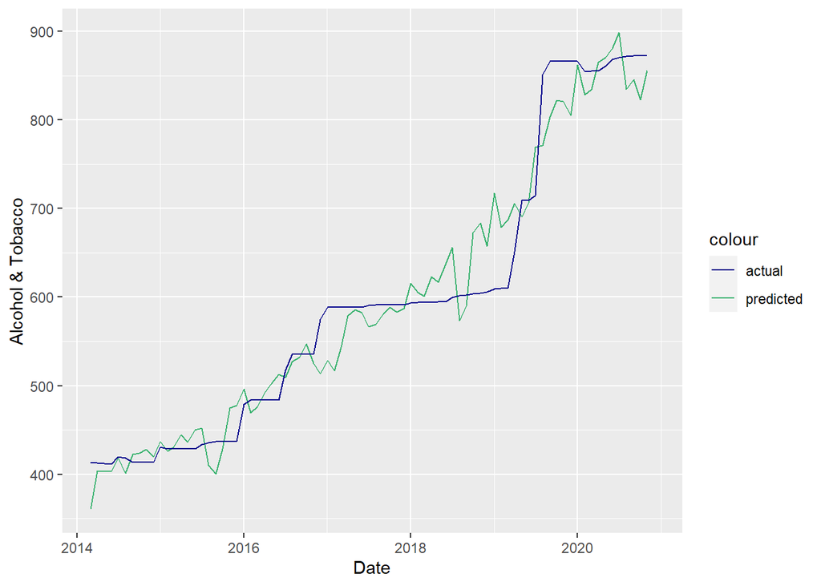

Considering the sudden increases this model seems to be working fairly well.

Finally regression model is applied to the data at hand to predict the price index of alcoholic beverages and tobacco in December 2020.

**And the predicted value of the regression model is:**

```r
alcandtobdata[82, fitted]
```

```
## [1] 897.7155
```

## 7.Conclusion

This study has came up with a prediction for the price index of alcoholic beverages by creating a regression model. Because the raise of the prices of alcohol and tobacco products are very sudden in Turkey, no regression model can perfectly predict the change. Model created in this study closely follows the actual data and is a good fit for predicting future price indexes.

To add the tax on alcoholic beverages were increased in the new year. Raises on alcohol and tobacco products are very sudden as it would be very hard to change the prices of these products regularly would be hard and require spending money. The prediction will probably be at fault since there wasn’t a big change in December and tax increase came in January.

### You can read the code from here.